# BKM Assignment

This document is an analysis of BKM data for the periods of January 2019 to June 2019. Data can be reached from https://bkm.com.tr/

### Importing the Libraries

Firstly, we have to import libraries that we will use throughout the analysis.

```r
library(rvest)
library(dplyr)
library(ggplot2)
```

### Importing the Data

The file is downloaded from the link and is assigned to a new variable called “table”.

```r
url <- "https://bkm.com.tr/secilen-aya-ait-sektorel-gelisim/?filter_year=2019&filter_month=1"
page <- read_html(url)
table <- html_table(page, fill = TRUE)[[4]][-c(1:2),]


for(i in 2:6) {
  url <- paste("https://bkm.com.tr/secilen-aya-ait-sektorel-gelisim/?filter_year=2019&filter_month=", i, sep = "")
  page <- read_html(url)
  table <- bind_rows(table, html_table(page, fill = TRUE)[[4]][-c(1:2),-1])
}

temp1 <- c(table%>% select(X1) %>%  filter(X1 != "NA"))
temp2 <- c(rep(temp1[["X1"]], times=6))
temp3 <- as.character(c(rep(seq(1:26), times=6)))


tmpTable <- table %>% mutate(X1 = temp2) %>% filter(X1 != "TOPLAM") %>% mutate(X6=temp3)


month_1 <- c(rep(1:6, times=1, each=26))
table <- tmpTable %>% mutate(month = month_1)


table2  <- as.data.frame(lapply(table, function(x) as.numeric(gsub(",", ".", gsub("\\.", "", x)))))
table2[,1] <- tmpTable[,1]
table2[,6] <- tmpTable[,6]
table <- table2

names(table) <- c("Sector", "TransactionCount_CC", "TransactionCount_DC", "TransactionAmount_CC", "TransactionAmount_DC", "Sector_ID", "Month")
```

Now let’s have a look at the beginning and end of the variable “table”.

```r
head(table)
```

```
##                                   Sector TransactionCount_CC
## 1                         ARABA KİRALAMA              256372
## 2 ARAÇ KİRALAMA-SATIŞ/SERVİS/YEDEK PARÇA             2967019
## 3           BENZİN VE YAKIT İSTASYONLARI            25277186
## 4                     BIREYSEL EMEKLILIK             2271587
## 5                           ÇEŞİTLİ GIDA            28362091
## 6                     DOĞRUDAN PAZARLAMA              757602
##   TransactionCount_DC TransactionAmount_CC TransactionAmount_DC Sector_ID
## 1               49296               195.13                14.77         1
## 2              642136              2185.84               127.16         2
## 3             8684036              5066.04               680.01         3
## 4                 697               716.42                 0.30         4
## 5            15221891              4473.98               673.70         5
## 6               40038               678.99                 7.81         6
##   Month
## 1     1
## 2     1
## 3     1
## 4     1
## 5     1
## 6     1
```

```r
tail(table)
```

```
##                                    Sector TransactionCount_CC
## 151        SEYAHAT ACENTELERİ/TAŞIMACILIK             7224598
## 152                               SİGORTA             4513691
## 153                      TELEKOMÜNİKASYON            17915719
## 154 YAPI MALZEMELERİ, HIRDAVAT, NALBURİYE             3786201
## 155                                 YEMEK            45687937
## 156                                 DİĞER             4984660
##     TransactionCount_DC TransactionAmount_CC TransactionAmount_DC
## 151             3152401              2311.90               620.16
## 152               42440              2919.50                11.44
## 153             3236866              1720.25               247.08
## 154             1347371              2784.08               199.37
## 155            43035091              2918.06              1497.76
## 156             1072573              1414.83               170.06
##     Sector_ID Month
## 151        21     6
## 152        22     6
## 153        23     6
## 154        24     6
## 155        25     6
## 156        26     6
```

### Analyses Related to the Data

- The first thing is to find the sectors with the highest transaction amount for both debit and credit cards.
- We can see that the sectors “MARKET VE ALIŞVERİŞ MERKEZLERİ (Sector ID=17)”, “GİYİM VE AKSESUAR (Sector ID=9)”, “BENZİN VE YAKIT İSTASYONLARI (Sector ID=3)”, “ÇEŞİTLİ GIDA (Sector ID=5)”, “HİZMET SEKTÖRLERİ (Sector ID=11)”, “YEMEK (Sector ID=25)”, “ELEKTRİK-ELEKTRONİK EŞYA, BİLGİSAYAR (Sector ID=8)” are the ones with the highest. So we can group the rest as “OTHER”.
- We can now find the fraction of the sum of transaction amounts for each sectors.
- Then we can visualise them in a pie chart.
- We can conclude that the sector of “MARKET VE ALIŞVERİŞ MERKEZLERİ” has a grave share with respect to the rest of the sector.

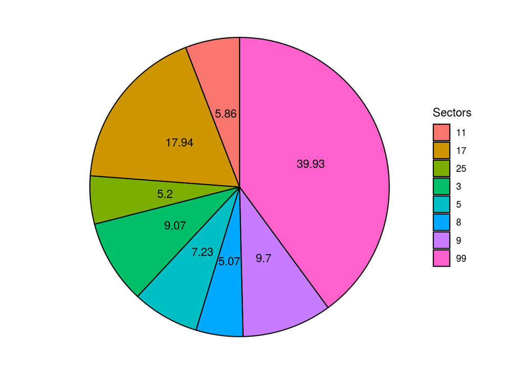

```r
table %>%
  filter (Month == 6) %>%
  transmute(Sector, Sector_ID, Tot_Tran_Amount = (TransactionAmount_CC + TransactionAmount_DC)) %>%
  arrange(desc(Tot_Tran_Amount)) %>%
  mutate(Sector_ID = case_when(Sector_ID %in% c("17","9","3","5","11","25","8") ~ Sector_ID, TRUE ~ "99")) %>%
  group_by(Sector_ID) %>%
  summarise(Tot_Tran_Amount = sum(Tot_Tran_Amount)) %>%
  mutate(Fra_Tran_Amount = round(Tot_Tran_Amount / sum(Tot_Tran_Amount)*100,2)) %>%
  ggplot(data = ., aes(x = "", y = Fra_Tran_Amount, fill = Sector_ID)) +
  geom_bar(width = 1, stat = "identity", color = "black") +
  coord_polar("y", start = 0)+
  geom_text(aes(x = "", y = Fra_Tran_Amount, label = Fra_Tran_Amount),position = position_stack(vjust = 0.5),color = "black")+
  labs(fill = "Sectors")+
  theme_void()
```

We can go deep with analyzing market sector with respoect to the months for 2019. There is an increase in the total transaction on May with respoect to other months.

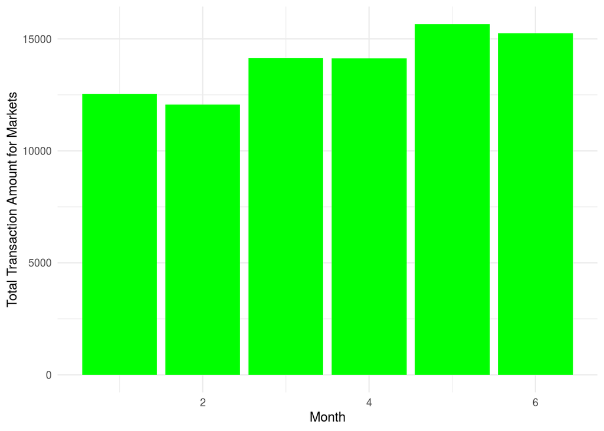

```r
table %>%
  filter (Sector_ID == 17) %>%
  mutate(Tot_Tran_Amount = (TransactionAmount_CC + TransactionAmount_DC)) %>%
  ggplot(data=., aes(x=Month, y=Tot_Tran_Amount)) +
  geom_bar(stat="identity", position=position_dodge(), fill="green")+
  labs(x="Month", y = "Total Transaction Amount for Markets") +
  theme_minimal()
```

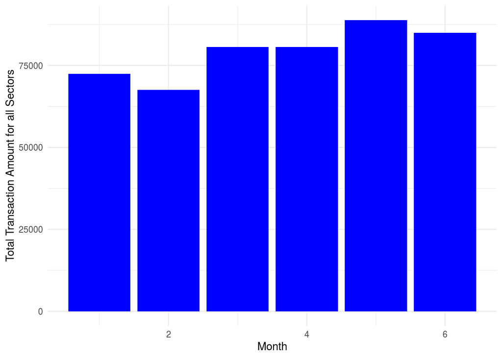

```r
table %>%
  group_by(Month) %>% summarize (Tot_Tran_Amount=sum(TransactionAmount_CC + TransactionAmount_DC)) %>%
  ggplot(data=., aes(x=Month, y=Tot_Tran_Amount)) +
  geom_bar(stat="identity", position=position_dodge(), fill="blue")+
  labs(x="Month", y = "Total Transaction Amount for all Sectors") +
  theme_minimal()
```

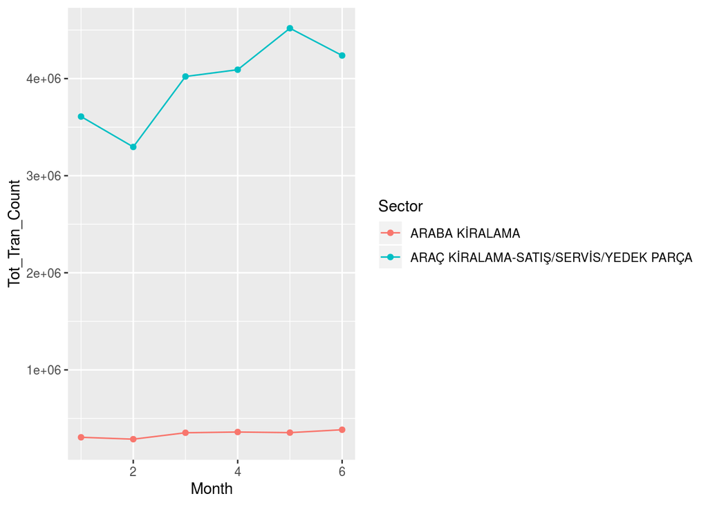

```r
table %>%
  filter (Sector_ID %in% c("1", "2")) %>%
  mutate(Tot_Tran_Count = (TransactionCount_CC + TransactionCount_DC)) %>%
  ggplot(data=., aes(x=Month, y=Tot_Tran_Count, group=Sector)) +
  geom_line(aes(color=Sector))+
  geom_point(aes(color=Sector))
```